# Primer R Markdown

Ivan Arriola

2023-03-25

# Ejercicio 1

1. Crear una carpeta en el disco T en la carpeta stat_nt que se llame Rmarkdown, si no tienen disco T o U hagan la carpeta en el escritorio.
2. Crear un proyecto de RStudio en la carpeta Rmarkdown, el nombre del proyecto también debe ser RMarkdown
3. Abrir un archivo de Rmarkdown que compile a pdf.
4. En YAML metadata: • Título del documento: Primer R Markdown • Autor: Nombre y apellido
5. Compilar (render) y ver que el documento sale bien en pdf

# Ejercicio 2

1. Incluir una sección que se llame “Incluir imagen”
2. Seleccionen una imagen que les guste de internet y guardarla en la carpeta donde está el proyecto.
3. Inluí la imagen en la sección con una linea de texto de porqué le gusta la imagen

# Incluir Imagen

## Ada Lovelace

[figure not shown]

Ada Lovelace

Me gusta esta foto porque es un retrato de la primera programadora de la historia

# Ejercicio 3

Ahora incluir una nueva sección que se llame “Chunck con código de R” 1. Incluir un chunk con código en R que haga el gráfico siguiente: Con los datos mpg que se encuentran disponible en ggplot2 hacer un scatterplot de hwy vs cty 2. La figura tiene que tener 5 de alto y 5 de ancho. 3. Cuando compile el archivo asegurate que salga el código de R.

# Chunck con código de R”

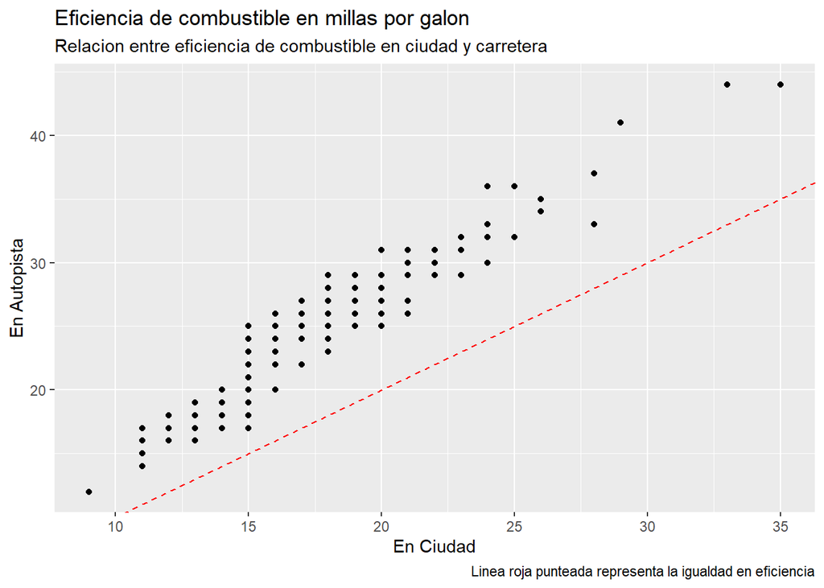

```r
library(ggplot2)
data(mpg)

ggplot(data=mpg, aes(x=cty, y=hwy)) +
  geom_point() +
  labs(x="En Ciudad",
       y="En Autopista",
       title="Eficiencia de combustible en millas por galon",
       subtitle="Relacion entre eficiencia de combustible en ciudad y carretera",
       caption="Linea roja punteada representa la igualdad en eficiencia") +
  geom_abline(slope = 1, intercept = 0, linetype = "dashed", color = "red")
```

# Ejercicio 4

Ahora incluir una nueva sección que se llame “Inluir una tabla” 1. Con los datos de mpg seleccione las filas 1:5 y las columnas de 1:5 y haga una tabla usando xtable 2. Cuando compile el archivo asegurate que salga el código de R

# Inluir una tabla

```r
library(xtable)
mpg_xt <- xtable(mpg[1:5, 1:5])

mpg_xt
```

| manufacturer | model | displ | year | cyl |
| --- | --- | --- | --- | --- |
| audi | a4 | 1.8 | 1999 | 4 |
| audi | a4 | 1.8 | 1999 | 4 |
| audi | a4 | 2.0 | 2008 | 4 |
| audi | a4 | 2.0 | 2008 | 4 |
| audi | a4 | 2.8 | 1999 | 6 |